# Machine Learning Hw1

A look into Linear and Logistic Regression, and Clustering.

Peter Sullivan  
2022-02-13

### Question 2. Exercise 1.

For each of parts (a) through (d), indicate whether we would generally expect the performance of a flexible statistical learning method to be better or worse than an inflexible method. Justify your answer.

##### (a)

The sample size n is extremely large, and the number of predictors p is small.

I would expect it to be better, as flexible models require lots of more data. So a large n would be beneficial for a flexible model.

##### (b)

The number of predictors p is extremely large, and the number of observations n is small.

For this I would recommend a more rigid model with the small n. The large number of p is also worrying for a flexible model. As shown in the text book in figure 2.6, large amount of predictors can cause the model to overfit.

##### (c)

The relationship between the predictors and response is highly non-linear.

I would expect a better performance form a flexible model. Lasso and least squares run better on linear data, which means the more flexible models will perform better.

##### (d)

The variance of the error terms, i.e. σ2 = Var(ϵ), is extremely high.

High Variance means we will have a lot of points above and below the line of best fit. If we were to use a more flexible model, we would see something similar to the high predictors p, overfitting. So a more flexible model would perform worse.

### ISLR Ch. 2, exercise 2

Explain whether each scenario is a classification or regression problem, and indicate whether we are most interested in inference or prediction. Finally, provide n and p.

##### (a)

We collect a set of data on the top 500 firms in the US. For each firm we record profit, number of employees, industry and the CEO salary. We are interested in understanding which factors affect CEO salary.

n = # of firms, 500 p = profit, # of employees, industry Regression Inference

This is a regression problem. We are not trying to classify the CEO salary into bands, or group the company salarys to similar ones. We are trying to understand how these predictors correlate to the dependent variable, CEO salary. We are most interested in inference.

##### (b)

We are considering launching a new product and wish to know whether it will be a success or a failure. We collect data on 20 similar products that were previously launched. For each product we have recorded whether it was a success or failure, price charged for the product, marketing budget, competition price, and ten other variables.

n = # of products, 20 p = price, marketing budget, competition price, ten other variables Classification Prediction

This is a classification problem. We are trying to learn from the predictors to label a product as a success or failure. If we were trying to predict the probalitlity of success and failure, then I believe that would be a logit regression. We are most interested in prediction.

##### (c)

We are interested in predicting the % change in the USD/Euro exchange rate in relation to the weekly changes in the world stock markets. Hence we collect weekly data for all of 2012. For each week we record the % change in the USD/Euro, the % change in the US market, the % change in the British market, and the % change in the German market.

n = # of weeks recorded, 1 year, 52 p = % change of us, british and german market

This is a regression problem. We are trying to predict a number based on predictors. This is a prediciton problem.

### ISLR Ch. 2, exercise 7

The table below provides a training data set containing six observations, three predictors, and one qualitative response variable.

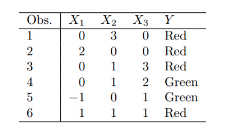

Suppose we wish to use this data set to make a prediction for Y when X1 = X2 = X3 = 0 using K-nearest neighbors.

##### (a)

Compute the Euclidean distance between each observation and the test point, X1 = X2 = X3 = 0.

```r
dist<- function(x,y,z){
  distance <- (x^2+y^2+z^2)^(1/2)

}

o1<- dist(0,3,0)
o2 <- dist(2,0,0)
o3<- dist(0,1,3)
o4<- dist(0,1,2)
o5 <- dist(-1,0,1)
o6 <- dist(1,1,1)


cbind(o1,o2, o3,o4,o5,o6)
```

```
     o1 o2       o3       o4       o5       o6
[1,]  3  2 3.162278 2.236068 1.414214 1.732051
```

##### (b)

What is our prediction with K = 1? Why?

If we use K =1, then the nearest observation from 0,0,0 is the green observation at -1,0,1.

Predict Green.

##### (c)

What is our prediction with K = 3? Why?

We would use observations 2, 5, and 6 as they are the closest to the center point. These are red, green, and red. So, we would predict red.

4. If the Bayes decision boundary in this problem is highly nonlinear, then would we expect the best value for K to be large or small? Why?

As the K value becomes large, we expect the model to become more linear. So a smaller K would work better for a highly nonlinear model.

### ISLR Ch. 2, exercise 10

This exercise involves the Boston housing data set. ##### (a) To begin, load in the Boston data set. The Boston data set is part of the ISLR2 library.

```r
library(ISLR2)
head(Boston)
```

```
     crim zn indus chas   nox    rm  age    dis rad tax ptratio lstat
1 0.00632 18  2.31    0 0.538 6.575 65.2 4.0900   1 296    15.3  4.98
2 0.02731  0  7.07    0 0.469 6.421 78.9 4.9671   2 242    17.8  9.14
3 0.02729  0  7.07    0 0.469 7.185 61.1 4.9671   2 242    17.8  4.03
4 0.03237  0  2.18    0 0.458 6.998 45.8 6.0622   3 222    18.7  2.94
5 0.06905  0  2.18    0 0.458 7.147 54.2 6.0622   3 222    18.7  5.33
6 0.02985  0  2.18    0 0.458 6.430 58.7 6.0622   3 222    18.7  5.21
  medv
1 24.0
2 21.6
3 34.7
4 33.4
5 36.2
6 28.7
```

```r
#?Boston
```

How many rows are in this data set? How many columns? What do the rows and columns represent?

```r
dim(Boston)
```

```
[1] 506  13
```

```r
colnames(Boston)
```

```
 [1] "crim"    "zn"      "indus"   "chas"    "nox"     "rm"
 [7] "age"     "dis"     "rad"     "tax"     "ptratio" "lstat"
[13] "medv"
```

```r
#head(Boston)
```

Each row is a case.

##### (b)

Make some pairwise scatterplots of the predictors (columns) in this data set. Describe your findings.

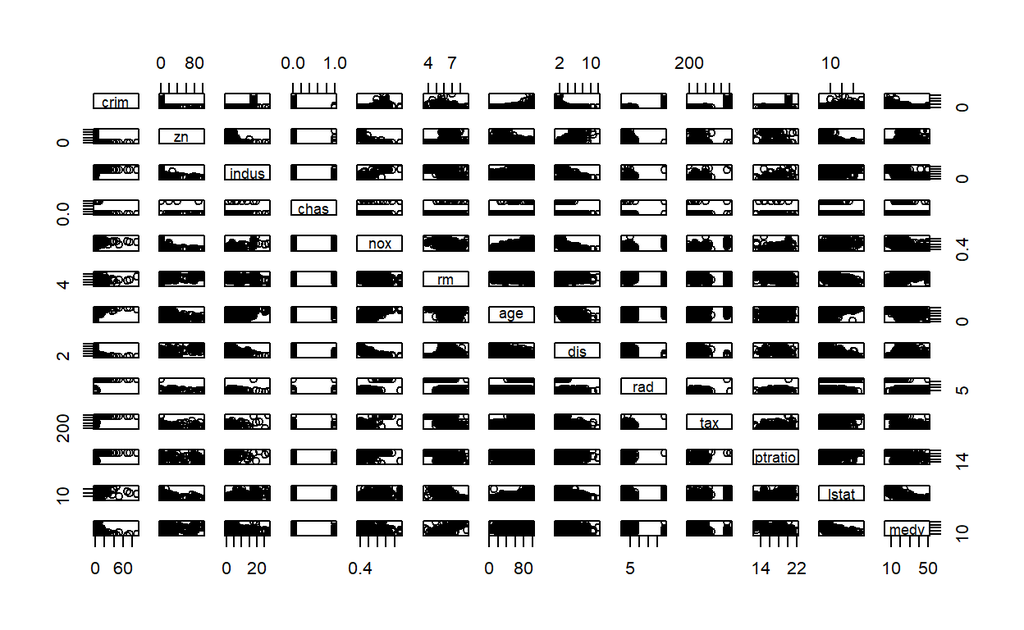

```r
pairs(Boston)
```

Initial Plot is hard to interpret. Lets trim down to these variables.

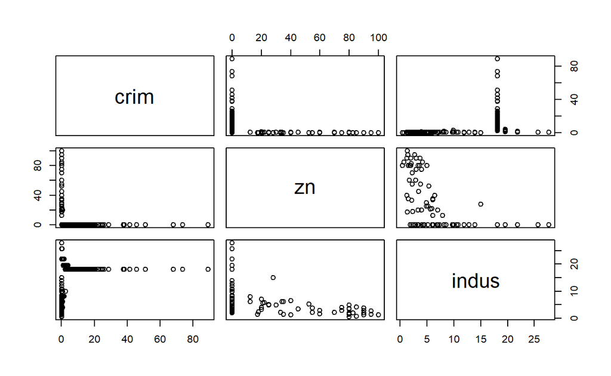

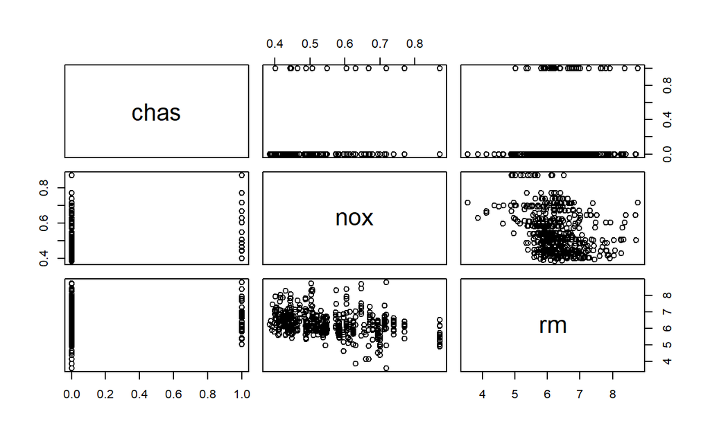

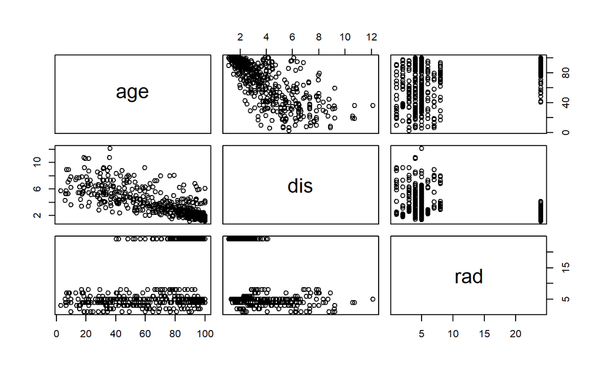

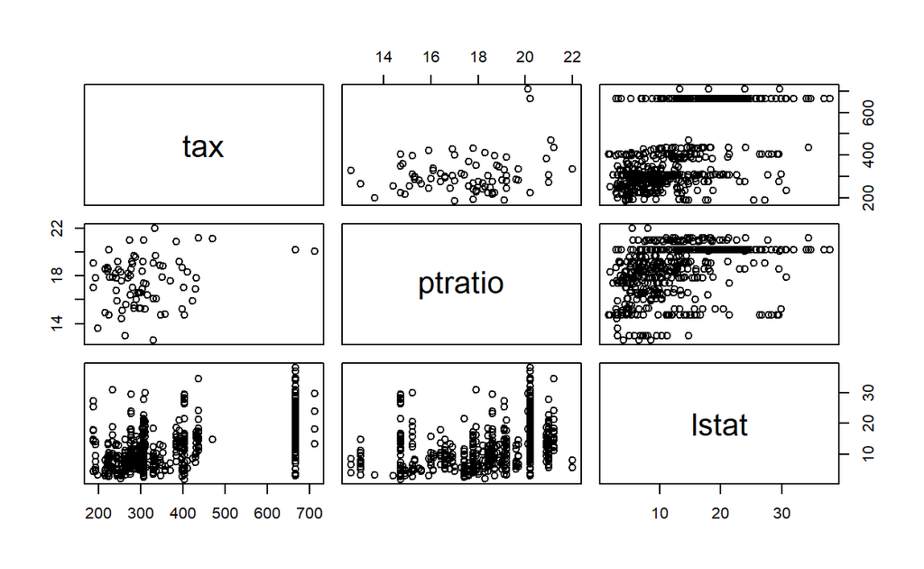

```r
columns <- colnames(Boston)


x = 0
group = NULL
for(i in columns){
  #print(i)
  x <- x+1
  #print(x)
  group <- cbind(group,i)

  if(x%%3 == 0){
    #print(x)
    #pairs(group)
    #print(group)
    df <- Boston[,colnames(Boston) %in% group]
    pairs(df)
    group <- NULL


  }


}
```

Possible Correlation between Age and dis, Zn and indus and possibly nox an rm.

##### (c)

Are any of the predictors associated with per capita crime rate? If so, explain the relationship. Lets try using the cor function.

```r
head(cor(Boston),1)
```

```
     crim         zn     indus        chas       nox         rm
crim    1 -0.2004692 0.4065834 -0.05589158 0.4209717 -0.2192467
           age        dis       rad       tax   ptratio     lstat
crim 0.3527343 -0.3796701 0.6255051 0.5827643 0.2899456 0.4556215
           medv
crim -0.3883046
```

##### (d)

Do any of the census tracts of Boston appear to have particularly high crime rates? Tax rates? Pupil-teacher ratios? Comment on the range of each predictor.

```r
summary(Boston)
```

```
      crim                zn             indus
 Min.   : 0.00632   Min.   :  0.00   Min.   : 0.46
 1st Qu.: 0.08205   1st Qu.:  0.00   1st Qu.: 5.19
 Median : 0.25651   Median :  0.00   Median : 9.69
 Mean   : 3.61352   Mean   : 11.36   Mean   :11.14
 3rd Qu.: 3.67708   3rd Qu.: 12.50   3rd Qu.:18.10
 Max.   :88.97620   Max.   :100.00   Max.   :27.74
      chas              nox               rm             age
 Min.   :0.00000   Min.   :0.3850   Min.   :3.561   Min.   :  2.90
 1st Qu.:0.00000   1st Qu.:0.4490   1st Qu.:5.886   1st Qu.: 45.02
 Median :0.00000   Median :0.5380   Median :6.208   Median : 77.50
 Mean   :0.06917   Mean   :0.5547   Mean   :6.285   Mean   : 68.57
 3rd Qu.:0.00000   3rd Qu.:0.6240   3rd Qu.:6.623   3rd Qu.: 94.08
 Max.   :1.00000   Max.   :0.8710   Max.   :8.780   Max.   :100.00
      dis              rad              tax           ptratio
 Min.   : 1.130   Min.   : 1.000   Min.   :187.0   Min.   :12.60
 1st Qu.: 2.100   1st Qu.: 4.000   1st Qu.:279.0   1st Qu.:17.40
 Median : 3.207   Median : 5.000   Median :330.0   Median :19.05
 Mean   : 3.795   Mean   : 9.549   Mean   :408.2   Mean   :18.46
 3rd Qu.: 5.188   3rd Qu.:24.000   3rd Qu.:666.0   3rd Qu.:20.20
 Max.   :12.127   Max.   :24.000   Max.   :711.0   Max.   :22.00
     lstat            medv
 Min.   : 1.73   Min.   : 5.00
 1st Qu.: 6.95   1st Qu.:17.02
 Median :11.36   Median :21.20
 Mean   :12.65   Mean   :22.53
 3rd Qu.:16.95   3rd Qu.:25.00
 Max.   :37.97   Max.   :50.00
```

The max crime rate is at 88% with a min at .006%. The crime rate data is heavily skewed by outliers, this can be seen by the very low median and a very high mean. The range of tax rates are from 187 per $10000 to 711. The pupil teacher ratio has a mean of 18.46 and a min of 12.6 and a max of 22.

##### (e)

How many of the census tracts in this data set bound the Charles river?

```r
head(Boston)
```

```
     crim zn indus chas   nox    rm  age    dis rad tax ptratio lstat
1 0.00632 18  2.31    0 0.538 6.575 65.2 4.0900   1 296    15.3  4.98
2 0.02731  0  7.07    0 0.469 6.421 78.9 4.9671   2 242    17.8  9.14
3 0.02729  0  7.07    0 0.469 7.185 61.1 4.9671   2 242    17.8  4.03
4 0.03237  0  2.18    0 0.458 6.998 45.8 6.0622   3 222    18.7  2.94
5 0.06905  0  2.18    0 0.458 7.147 54.2 6.0622   3 222    18.7  5.33
6 0.02985  0  2.18    0 0.458 6.430 58.7 6.0622   3 222    18.7  5.21
  medv
1 24.0
2 21.6
3 34.7
4 33.4
5 36.2
6 28.7
```

```r
Boston %>% filter(chas==1) %>% dim()
```

```
[1] 35 13
```

There are 35 census tracts bound by the charles river.

##### (f)

What is the median pupil-teacher ratio among the towns in this data set?

```r
median(Boston$ptratio)
```

```
[1] 19.05
```

```r
summary(Boston$ptratio)
```

```
   Min. 1st Qu.  Median    Mean 3rd Qu.    Max.
  12.60   17.40   19.05   18.46   20.20   22.00
```

The Median pratio is 19.05.

##### (g)

Which census tract of Boston has lowest median value of owneroccupied homes? What are the values of the other predictors for that census tract, and how do those values compare to the overall ranges for those predictors? Comment on your findings.

```r
# 2 census tracts with lowest median value of owner occupied homes
Boston %>% arrange(medv) %>% slice(1:2)
```

```
     crim zn indus chas   nox    rm age    dis rad tax ptratio lstat
1 38.3518  0  18.1    0 0.693 5.453 100 1.4896  24 666    20.2 30.59
2 67.9208  0  18.1    0 0.693 5.683 100 1.4254  24 666    20.2 22.98
  medv
1    5
2    5
```

I found 2 census tracts with the lowest median value of owner occupied homes at 5. The crime rates were relatively high at 38 and 67. The tax rates were also very high in this area, which is surprising with a very low median home value. Age also seems to be maxed out for these at the 100 value. So these are highly taxed, very old houses, with a high crime rate.

##### (h)

In this data set, how many of the census tracts average more than seven rooms per dwelling? More than eight rooms per dwelling? Comment on the census tracts that average more than eight rooms per dwelling.

```r
# higher than 7 per dwelling

Boston %>% filter(rm >= 7) %>%  dim()
```

```
[1] 64 13
```

```r
# higher then 8 per dwelling


Boston %>% filter(rm >= 8) %>% dim()
```

```
[1] 13 13
```

```r
Boston%>% filter(rm >=8) %>% summary()
```

```
      crim               zn            indus             chas
 Min.   :0.02009   Min.   : 0.00   Min.   : 2.680   Min.   :0.0000
 1st Qu.:0.33147   1st Qu.: 0.00   1st Qu.: 3.970   1st Qu.:0.0000
 Median :0.52014   Median : 0.00   Median : 6.200   Median :0.0000
 Mean   :0.71879   Mean   :13.62   Mean   : 7.078   Mean   :0.1538
 3rd Qu.:0.57834   3rd Qu.:20.00   3rd Qu.: 6.200   3rd Qu.:0.0000
 Max.   :3.47428   Max.   :95.00   Max.   :19.580   Max.   :1.0000
      nox               rm             age             dis
 Min.   :0.4161   Min.   :8.034   Min.   : 8.40   Min.   :1.801
 1st Qu.:0.5040   1st Qu.:8.247   1st Qu.:70.40   1st Qu.:2.288
 Median :0.5070   Median :8.297   Median :78.30   Median :2.894
 Mean   :0.5392   Mean   :8.349   Mean   :71.54   Mean   :3.430
 3rd Qu.:0.6050   3rd Qu.:8.398   3rd Qu.:86.50   3rd Qu.:3.652
 Max.   :0.7180   Max.   :8.780   Max.   :93.90   Max.   :8.907
      rad              tax           ptratio          lstat
 Min.   : 2.000   Min.   :224.0   Min.   :13.00   Min.   :2.47
 1st Qu.: 5.000   1st Qu.:264.0   1st Qu.:14.70   1st Qu.:3.32
 Median : 7.000   Median :307.0   Median :17.40   Median :4.14
 Mean   : 7.462   Mean   :325.1   Mean   :16.36   Mean   :4.31
 3rd Qu.: 8.000   3rd Qu.:307.0   3rd Qu.:17.40   3rd Qu.:5.12
 Max.   :24.000   Max.   :666.0   Max.   :20.20   Max.   :7.44
      medv
 Min.   :21.9
 1st Qu.:41.7
 Median :48.3
 Mean   :44.2
 3rd Qu.:50.0
 Max.   :50.0
```

There are 64 census tracts that are 7 or more rooms per dwelling, but only 13 with 8 or more rooms per dwelling. For the 13 dwellings with 8 or mor rooms per dweling I saw the following statistics: - max crime rate of 3.4, mean of .718 -max lstat of 7.44, mean of 4.3 - max mdv value of 50, average of 44

These seem to be a safer neighborhood, with a higher status and more expensive homes.

### ISLR Ch. 3, exercise 1

Describe the null hypotheses to which the p-values given in Table 3.4 correspond. Explain what conclusions you can draw based on these p-values. Your explanation should be phrased in terms of sales, TV, radio, and newspaper, rather than in terms of the coefficients of the linear model.

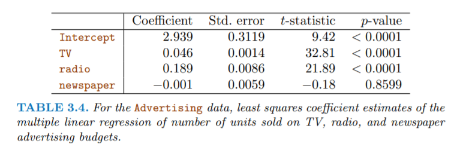

All independent variables =0. Alternative hypothesis - at least one independent variable is non-zero.

TV and radio are both statistically significant, which means the null hypothesis can be rejected. We can assume there is some correlation between TV and Radio. Newspaper’s pvalue is above .05 which means the independent variable is not statistically significant. Which means we accept the null hypothesis, and there is no correlation between newspaper and sales.

### ISLR Ch. 3, exercise 3

Suppose we have a data set with five predictors, X1 = GPA, X2 =IQ, X3 = Level (1 for College and 0 for High School), X4 = Interaction between GPA and IQ, and X5 = Interaction between GPA and Level. The response is starting salary after graduation (in thousands of dollars). Suppose we use least squares to fit the model, and get βˆ0 = 50, βˆ1 = 20, βˆ2 = 0.07, βˆ3 = 35, βˆ4 = 0.01, βˆ5 = −10.

Salary = 50 + GPA * 20 + IQ +.07 + Level * 35 + .01 * GPA:IQ -10 * GPA:Level ##### (a) Which answer is correct, and why?

##### i.

For a fixed value of IQ and GPA, high school graduates earn more, on average, than college graduates.

fixed iq and gpa iq, gpa = 1 S = 70.08 + level* 35 -10 * level

College = 1 highschool = 0

college - S = 70.08 +35 - 10 Highschool - S = 70

**This one is not true.**

##### ii.

For a fixed value of IQ and GPA, college graduates earn more, on average, than high school graduates.

##### iii.

For a fixed value of IQ and GPA, high school graduates earn more, on average, than college graduates provided that the GPA is high enough.

###### iv.

For a fixed value of IQ and GPA, college graduates earn more, on average, than high school graduates provided that the GPA is high enough.

**This one is wrong.**

##### (b)

Predict the salary of a college graduate with IQ of 110 and a GPA of 4.0.

```r
GPA = 4
IQ =110
Level = 1

Salary = 50 + GPA * 20  + IQ +.07 + Level * 35 + .01 * GPA*IQ  -10 * GPA*Level

Salary
```

```
[1] 239.47
```

Salary = 239K

##### (c)

True or false: Since the coefficient for the GPA/IQ interaction term is very small, there is very little evidence of an interaction effect. Justify your answer.

This is false. .01 is a relative term. for the problem above we had an IQ of 110. GPA ranging from 1 - 4 would give the range of 1.1K to 4.4 K.

### ISLR Ch. 3, exercise 15

This problem involves the Boston data set, which we saw in the lab for this chapter. We will now try to predict per capita crime rate using the other variables in this data set. In other words, per capita crime rate is the response, and the other variables are the predictors.

##### (a)

For each predictor, fit a simple linear regression model to predict the response. Describe your results. In which of the models is there a statistically significant association between the predictor and the response? Create some plots to back up your assertions.

Predict Crime Rate

```r
#Boston
#colnames(Boston)
Dependent_variable <- Boston %>% dplyr::select(crim)
predictors <- Boston %>% dplyr::select(-crim)
#Dependent_variable %>% head()
#predictors %>% head()


predictors_varname <- colnames(predictors)



outcome <- "crim"
models <- lapply(paste(outcome," ~", predictors_varname), as.formula)
y <- NULL


for (model in models){
  linearmodel <- lm(model, data = Boston)
  x <- summary(linearmodel)
  print(x$coefficients)
  #print(paste(format(model), "R^2 value: ", round(x$r.squared,3)*100, "%"))
  y <- rbind(y, data.frame(variable = as.character(model[3]),
              "Rvalue_Percent" = round(x$r.squared,3)*100))
}
```

```
               Estimate Std. Error   t value     Pr(>|t|)
(Intercept)  4.45369376  0.4172178 10.674746 4.037668e-24
zn          -0.07393498  0.0160946 -4.593776 5.506472e-06
              Estimate Std. Error   t value     Pr(>|t|)
(Intercept) -2.0637426 0.66722830 -3.093008 2.091266e-03
indus        0.5097763 0.05102433  9.990848 1.450349e-21
             Estimate Std. Error   t value     Pr(>|t|)
(Intercept)  3.744447  0.3961111  9.453021 1.239505e-19
chas        -1.892777  1.5061155 -1.256727 2.094345e-01
             Estimate Std. Error   t value     Pr(>|t|)
(Intercept) -13.71988   1.699479 -8.072992 5.076814e-15
nox          31.24853   2.999190 10.418989 3.751739e-23
             Estimate Std. Error   t value     Pr(>|t|)
(Intercept) 20.481804  3.3644742  6.087669 2.272000e-09
rm          -2.684051  0.5320411 -5.044819 6.346703e-07
              Estimate Std. Error   t value     Pr(>|t|)
(Intercept) -3.7779063 0.94398472 -4.002084 7.221718e-05
age          0.1077862 0.01273644  8.462825 2.854869e-16
             Estimate Std. Error   t value     Pr(>|t|)
(Intercept)  9.499262  0.7303972 13.005611 1.502748e-33
dis         -1.550902  0.1683300 -9.213458 8.519949e-19
              Estimate Std. Error   t value     Pr(>|t|)
(Intercept) -2.2871594 0.44347583 -5.157349 3.605846e-07
rad          0.6179109 0.03433182 17.998199 2.693844e-56
               Estimate  Std. Error   t value     Pr(>|t|)
(Intercept) -8.52836909 0.815809392 -10.45387 2.773600e-23
tax          0.02974225 0.001847415  16.09939 2.357127e-47
              Estimate Std. Error   t value     Pr(>|t|)
(Intercept) -17.646933  3.1472718 -5.607057 3.395255e-08
ptratio       1.151983  0.1693736  6.801430 2.942922e-11
              Estimate Std. Error   t value     Pr(>|t|)
(Intercept) -3.3305381 0.69375829 -4.800718 2.087022e-06
lstat        0.5488048 0.04776097 11.490654 2.654277e-27
              Estimate Std. Error  t value     Pr(>|t|)
(Intercept) 11.7965358 0.93418916 12.62757 5.934119e-32
medv        -0.3631599 0.03839017 -9.45971 1.173987e-19
```

```r
y %>% arrange(desc(Rvalue_Percent))
```

```
   variable Rvalue_Percent
1       rad           39.1
2       tax           34.0
3     lstat           20.8
4       nox           17.7
5     indus           16.5
6      medv           15.1
7       dis           14.4
8       age           12.4
9   ptratio            8.4
10       rm            4.8
11       zn            4.0
12     chas            0.3
```

When predicting crime I found the following predictors statistically significant: - indus - zn - medv - lstat - pratio - tax - rad - dis - age - rm -nox

##### (b)

Fit a multiple regression model to predict the response using all of the predictors. Describe your results. For which predictors can we reject the null hypothesis H0 : βj = 0?

```r
lm.fit <- lm(data = Boston, crim ~ .)
summary(lm.fit)
```

```
Call:
lm(formula = crim ~ ., data = Boston)

Residuals:
   Min     1Q Median     3Q    Max
-8.534 -2.248 -0.348  1.087 73.923

Coefficients:
              Estimate Std. Error t value Pr(>|t|)
(Intercept) 13.7783938  7.0818258   1.946 0.052271 .
zn           0.0457100  0.0187903   2.433 0.015344 *
indus       -0.0583501  0.0836351  -0.698 0.485709
chas        -0.8253776  1.1833963  -0.697 0.485841
nox         -9.9575865  5.2898242  -1.882 0.060370 .
rm           0.6289107  0.6070924   1.036 0.300738
age         -0.0008483  0.0179482  -0.047 0.962323
dis         -1.0122467  0.2824676  -3.584 0.000373 ***
rad          0.6124653  0.0875358   6.997 8.59e-12 ***
tax         -0.0037756  0.0051723  -0.730 0.465757
ptratio     -0.3040728  0.1863598  -1.632 0.103393
lstat        0.1388006  0.0757213   1.833 0.067398 .
medv        -0.2200564  0.0598240  -3.678 0.000261 ***
---
Signif. codes:  0 '***' 0.001 '**' 0.01 '*' 0.05 '.' 0.1 ' ' 1

Residual standard error: 6.46 on 493 degrees of freedom
Multiple R-squared:  0.4493,    Adjusted R-squared:  0.4359
F-statistic: 33.52 on 12 and 493 DF,  p-value: < 2.2e-16
```

For zn, dis, rad, and medv we can reject the null hypothesis that Beta = 0, as there is statistically significance and correlation between those variables and crime rate.

##### (c)

How do your results from (a) compare to your results from (b)? Create a plot displaying the univariate regression coefficients from (a) on the x-axis, and the multiple regression coefficients from (b) on the y-axis. That is, each predictor is displayed as a single point in the plot. Its coefficient in a simple linear regression model is shown on the x-axis, and its coefficient estimate in the multiple linear regression model is shown on the y-axis.

First step is gathering the coefficients from each model.

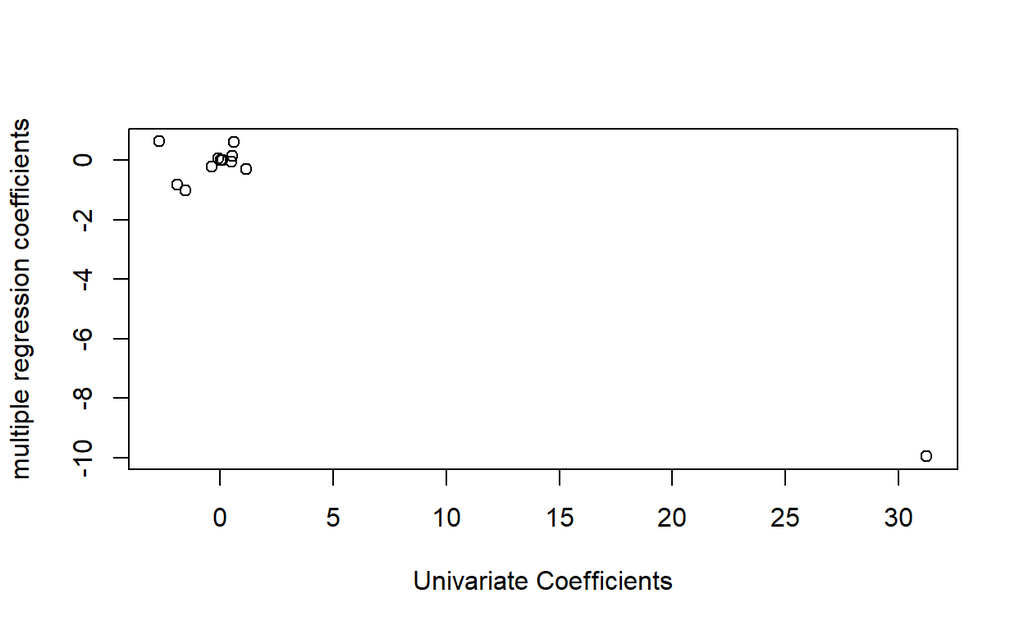

```r
multiple <- lm(data = Boston, crim ~ .)
x <- summary(multiple)



multi_coef <- data.frame(multi_coef = x$coefficients[2:13,1])
#multi_coef

#now need coefficients from previous models

outcome <- "crim"
models <- lapply(paste(outcome," ~", predictors_varname), as.formula)
coef_matrix <- NULL


for (model in models){
  linearmodel <- lm(model, data = Boston)
  x <- summary(linearmodel)
  #print(x$coefficients[2,4])

  coef_matrix <- rbind(coef_matrix, data.frame(predictor = as.character(model[3]),
              coef = x$coefficients[2,1]))
}

#multi_coef
#coef_matrix

plot(coef_matrix$coef,multi_coef$multi_coef, xlab = "Univariate Coefficients", ylab = "multiple regression coefficients")
```

##### (d)

Is there evidence of non-linear association between any of the predictors and the response? To answer this question, for each predictor X, fit a model of the form Y = β0 + β1X + β2X2 + β3X3 + ϵ.

```r
library(car)
lm.fit <- lm(data = Boston, crim ~.)
vif(lm.fit)
```

```
      zn    indus     chas      nox       rm      age      dis
2.323944 3.983627 1.093242 4.546642 2.201688 3.088678 4.280979
     rad      tax  ptratio    lstat     medv
7.029796 9.195493 1.969732 3.538098 3.663205
```

Possible non-linearity due to tax, and may rad.

Another way to look into this is using the ploy function for each coefficient.

```r
#practice

lm.poly <- lm(data = Boston, crim ~ poly(lstat,5))
z <- summary(lm.poly)
#data.frame(z$coefficients)

#Boston %>% colnames()



(lm.poly <- lm(data = Boston, crim ~ poly(lstat,5))) %>% summary()
```

```
Call:
lm(formula = crim ~ poly(lstat, 5), data = Boston)

Residuals:
    Min      1Q  Median      3Q     Max
-13.682  -1.848  -0.547  -0.049  82.707

Coefficients:
                Estimate Std. Error t value Pr(>|t|)
(Intercept)       3.6135     0.3368  10.729   <2e-16 ***
poly(lstat, 5)1  88.0697     7.5758  11.625   <2e-16 ***
poly(lstat, 5)2  15.8882     7.5758   2.097   0.0365 *
poly(lstat, 5)3 -11.5740     7.5758  -1.528   0.1272
poly(lstat, 5)4  15.5158     7.5758   2.048   0.0411 *
poly(lstat, 5)5  16.8403     7.5758   2.223   0.0267 *
---
Signif. codes:  0 '***' 0.001 '**' 0.01 '*' 0.05 '.' 0.1 ' ' 1

Residual standard error: 7.576 on 500 degrees of freedom
Multiple R-squared:  0.232, Adjusted R-squared:  0.2243
F-statistic:  30.2 on 5 and 500 DF,  p-value: < 2.2e-16
```

```r
#(lm.poly <- lm(data = Boston, crim ~ poly(zn,5))) %>% summary()
#(lm.poly <- lm(data = Boston, crim ~ poly(indus,5))) %>% summary()
#lm.poly <- lm(data = Boston, crim ~ poly(chas,2)) Won't let me run poly
#(lm.poly <- lm(data = Boston, crim ~ poly(nox,5))) %>% summary()
#(lm.poly <- lm(data = Boston, crim ~ poly(rm,5))) %>% summary()
#(lm.poly <- lm(data = Boston, crim ~ poly(age,5)))%>% summary()
#(lm.poly <- lm(data = Boston, crim ~ poly(dis,5))) %>% summary()
#(lm.poly <- lm(data = Boston, crim ~ poly(rad,5))) %>% summary()
#(lm.poly <- lm(data = Boston, crim ~ poly(tax,5)))%>% summary()
#(lm.poly <- lm(data = Boston, crim ~ poly(ptratio,5)))%>% summary()
#(lm.poly <- lm(data = Boston, crim ~ poly(black,5))) %>% summary()
#(lm.poly <- lm(data = Boston, crim ~ poly(medv,5))) %>% summary()
```

I originally ran the summar on each model using the polystat. I then commented the code after, since there is no need to have 14 summarys in a row on the html document.

### ISLR Ch. 4, exercise 4

When the number of features p is large, there tends to be a deterioration in the performance of KNN and other local approaches that perform prediction using only observations that are near the test observation for which a prediction must be made. This phenomenon is known as the curse of dimensionality, and it ties into the fact that curse of dimensionality non-parametric approaches often perform poorly when p is large. We will now investigate this curse.

##### (a) Instructors answer via Piazza helped answer this problem.

Suppose that we have a set of observations, each with measurements on p = 1 feature, X. We assume that X is uniformly (evenly) distributed on [0, 1]. Associated with each observationis a response value. Suppose that we wish to predict a test observation’s response using only observations that are within 10 % of the range of X closest to that test observation. For instance, inorder to predict the response for a test observation with X = 0.6, we will use observations in the range [0.55, 0.65]. On average, what fraction of the available observations will we use to make the prediction?

– p =1, x uniformly distributed Observations are in the range of .55 to .65. This means that observations .45 to .55 is just as likely. .65 -.55 = .1. 1/10 of the available observations we will use to make the predcition.

##### B - Aanchal Setia from Piazza discussion

Now suppose that we have a set of observations, each with measurements on p = 2 features, X1 and X2. We assume that (X1, X2) are uniformly distributed on [0, 1] × [0, 1]. We wish to predict a test observation’s response using only observations that are within 10 % of the range of X1 and within 10 % of the range of X2 closest to that test observation. For instance, in order to predict the response for a test observation with X1 = 0.6 and X2 = 0.35, we will use observations in the range [0.55, 0.65] for X1 and in the range [0.3, 0.4] for X2. On average, what fraction of the available observations will we use to make the prediction?

For x1 we will use 10% range, and for x2 we will also use a 10% range.Therefore, on average we will have 10% of 10% of observations.

```r
.1*.1
```

```
[1] 0.01
```

##### C

Now suppose that we have a set of observations on p = 100 features. Again the observations are uniformly distributed on each feature, and again each feature ranges in value from 0 to 1. We wish to predict a test observation’s response using observations within the 10 % of each feature’s range that is closest to that test observation. What fraction of the available observations will we use to make the prediction?

P = 100 , range 0 to 1. Assuming that each response is using the 10% range p = 1 — .1 p =2 —- .1*.1 p = 3 —- .1* .1 *.1 p = n —- .1^n

```r
p = 100

.1^p
```

```
[1] 1e-100
```

There 1 E-100 of the available observations will be used to make the prediction.

##### D

Using your answers to parts (a)–(c), argue that a drawback of KNN when p is large is that there are very few training observations “near” any given test observation.

Based on the above results, if we have 100 features, we would need an extremely large data set to get point that are with in the 10% range of each other.

### ISLR Ch. 4, exercise 6

Suppose we collect data for a group of students in a statistics class with variables X1 = hours studied, X2 = undergrad GPA, and Y = receive an A. We fit a logistic regression and produce estimated coefficient, βˆ0 = −6, βˆ1 = 0.05, βˆ2 = 1.

##### (a)

Estimate the probability that a student who studies for 40 h and has an undergrad GPA of 3.5 gets an A in the class.

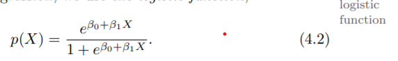

Logistic Funciton

```r
b_0 = -6
b_1 = .05
b_2 = 1
x1 = 40
x2 = 3.5

prob = exp(b_0+b_1*x1+b_2*x2)/(1+exp(b_0+b_1*x1*1+b_2*x2))
prob
```

```
[1] 0.3775407
```

There is a 37% probablity of receiving an A in this class assuming a 3.5 gpa and 40 hours of studying.

##### (b)

How many hours would the student in part (a) need to study to have a 50 % chance of getting an A in the class?

Manipulate the above equaiton to solve for x1.

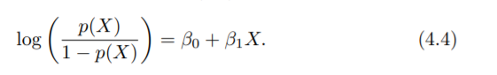

Log Odds

```r
b_0 = -6
b_1 = .05
b_2 = 1
prob = .5
x2 = 3.5

x1 = (log(prob/(1-prob))- b_0 - b_2*x2)/b_1
x1
```

```
[1] 50
```

Assuming the 3.5 gpa, we will need to study 50 hours to have a probability of getting an A at 50%.

### ISLR Ch. 4, exercise 9

This problem has to do with odds.

##### (a)

On average, what fraction of people with an odds of 0.37 of defaulting on their credit card payment will in fact default?

Odds = P(X)/1-P(X)  
odds* (1-P(X)) = P(x)  
odds - odds*p(x) = P(x)  
odds = p(x)(1+odds)  
p(x) = odds/(1+odds)

```r
odds = .37
x  = odds/(1+odds)
x
```

```
[1] 0.270073
```

.27 of people with an odds of .37 will default

##### (b)

Suppose that an individual has a 16 % chance of defaulting on her credit card payment. What are the odds that she will default? P(x) = .16 odds = P(x)/(1-P(x))

```r
x = .16
odds = x/(1-x)
odds
```

```
[1] 0.1904762
```

16 % of the people with an odds of .19 will default.